# El paquete `caret`

Master de Big Data

José Tomás Palma Méndez

13 de febrero de 2024

# 1 Indroducción

El paquete `caret` (Classification and Regresion Training) nos proporciona una serie de funciones que facilitan la resolución de problemas complejos de clasificación y regresión. El paquete `caret` utiliza funciones para construir modelos de clasificación y regresión proporcionadas por otros paquetes, cargando estos sólo cuando son necesarios, siempre y cuando estén instalados.

A través de las funciones ofrecidas por el paquete `caret` podemos realizar todos los pasos necesarios para construir un modelo de clasificación: visualización y análisis inicial de los datos, preprocesamiento, selección de variables, optimización de parámetros y evaluación. Una lista con las distintas técnicas de clasificación y regresión que podemos utilizar a través del paquete `caret`, así como los parámetros que requiere cada técnica, se puede ver en https://topepo.github.io/caret/available-models.html

**Paquetes necesarios:** `caret`, `partykit` y `pROC`.

# 2 Visualización

Para este guión vamos a utilizar el fichero generado en la fase de preprocesamiento al que le aplicamos la imputación por el método kNN.

```r
hepatitis.KnnImp <- read.csv("Datos/hepatitisKnnImp.csv", header = TRUE,
                             stringsAsFactors = TRUE)
```

Una vez cargada la tabla con los datos, podemos analizar los datos mediante gráficos de dispersión. Para realizar estos gráficos hay que utilizar la función `featurePlot()`:

```r
library(caret)
```

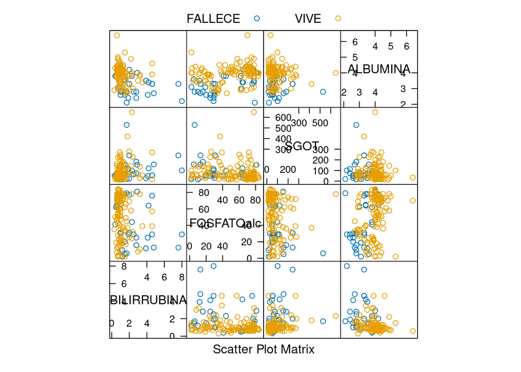

```r
cols_to_plot = c ("BILIRRUBINA","FOSFATOalc","SGOT","ALBUMINA")
featurePlot(x = hepatitis.KnnImp[,(names(hepatitis.KnnImp) %in% cols_to_plot)],
            y = hepatitis.KnnImp$PRONOSTICO,
            plot = "pairs",auto.key = list(columns = 2))
```

**Ejercicio 1:**

1. Prueba todas las opciones del parámetro `plot` `pairs`, `box`, `strip`, `density` y `ellipse`
2. ¿Se pueden extraer alguna conclusión de las gráficas anteriormente generadas?

# 3 Preprocesamiento.

El paquete `caret` también nos ofrece funciones que permiten realizar aplicar algunas técnicas de preprocesamiento. Concretamente, podemos realizar transformaciones de escala, centrado y reducción de la dimensionalidad por medio del análisis de componentes principales (ACP) o análisis de componentes independientes (ACI).

```r
set.seed(342)
trainIndex <- createDataPartition(hepatitis.KnnImp$PRONOSTICO,
                                  p = 0.66,
                                  list = FALSE,
                                  times = 1)
hepatitisTrain <- hepatitis.KnnImp[trainIndex,]
hepatitisTest <- hepatitis.KnnImp[-trainIndex,]
```

El primer parámetro indica en qué columna se encuentra la información sobre a qué clase pertenece cada objeto. El parámetro `p=0.66` indica la proporción de objetos que vamos a seleccionar. Con `list=FALSE` indicamos que no queremos que el resultado sea una lista, sino que devolverá un vector con los índices seleccionados. El parámetro `times` nos permite crear múltiples particiones. Una vez obtenido el vector con los índices seleccionados, ya podemos realizar la partición de los datos, seleccionando para el conjunto de entrenamiento aquellos objetos cuyos índices están incluidos en el vector de índices.

Para tareas de procesamiento vamos a utilizar la función `preProcess()`. Esta función determina los parámetros necesarios para realizar la transformación requerida, con lo que para transformar realmente los datos hay que utilizar posteriormente la función `predict()`. La función `preProcess` tiene los siguientes parámetros:

- `x`: matriz o data frame de datos. En el caso de clasificación hay que eliminar la columna que especifica la clase.
- `method`: que indica el método de preprocesamiento que vamos a utilizar: `BoxCox`, `center`, `scale`, `range`, `knnImpute`, `bagImpute`, `pca`, `ica` and `spatialSign`.
  - En el caso de realizar un análisis de componentes principales, (`method=pca`), tenemos que indicarle el número de componentes que vamos a utilizar, bien indicando un umbral para especificar el punto de corte del porcentaje acumulado de varianza, `tresh`, o indicando directamente el número de componentes que queremos, `pcaComp`. Las componentes recibirán los nombres `PC1`, `PC2`, ….
  - En el caso de realizar un análisis de componente independientes, (`method=ica`), necesitaremos indicar el número de componentes que queremos, `n.comp`. Las componentes recibirán los nombres `ICA1`, `ICA2`, ….
  - Para el caso de la imputación de valores, (`method=knnImpute`), necesitaríamos indicar el número de vecinos más cercanos a utilizar, `k`, además sólo se podrá aplicar para atributos numéricos siempre y cuando no existan elementos con todos sus valores desconocidos.
  - Para el caso de cambios de escala con el método `range`, los límites de la nueva escala hay que indicarlos a través del parámetro `rangeBounds` que espera un vector de dos elementos los límites de la nueva escala.

Por ejemplo, la siguiente instrucción nos permite reducir el número de características mediante ACP, seleccionando el conjunto de componentes principales que acumulen el 95% de la varianza:

```r
hepatitisPCA <- preProcess(hepatitis.KnnImp[1:ncol(hepatitis.KnnImp)-1],
                method = "pca",thresh = 0.95)
print(hepatitisPCA)
```

```
## Created from 155 samples and 19 variables
##
## Pre-processing:
##   - centered (6)
##   - ignored (13)
##   - principal component signal extraction (6)
##   - scaled (6)
##
## PCA needed 6 components to capture 95 percent of the variance
```

Obsérvese que para efectuar el ACP hemos eliminado la última columna de la matriz de datos que es la que contiene la información sobre las clases. Una vez realizado el proceso ACP, sólo tenemos que transformar los datos y volver a añadir la columna que define las clases de los objetos:

```r
PCATrain <- predict(hepatitisPCA,hepatitisTrain[,1:ncol(hepatitisTrain)-1])
PCATest <- predict(hepatitisPCA,hepatitisTest[,1:ncol(hepatitisTest)-1])
PCATrain <- data.frame(PCATrain,PRONOSTICO=hepatitisTrain$PRONOSTICO)
PCATest <- data.frame(PCATest,PRONOSTICO=hepatitisTest$PRONOSTICO)
```

El paquete `caret` también nos ofrece funciones que nos permiten determinar las características que poseen varianza cercana a cero, `nearZeroVar()`, identificar características correladas, `findCorrelation()` o detectar dependencias lineales, `findLinearCombos()`. Estas funciones también se pueden aplicar a través de la función `preProcess()` con los métodos `zv`, `nzv` y `corr`.

**Ejercicio 2:**

1. ¿Cómo podríamos generar un conjunto de datos qué solo contenga las componentes principales seleccionadas y el atributo que identifica la clase? Realiza el proceso para los conjuntos de entrenamiento y prueba.
2. Crea un gráfico en el qué se muestren las cuatro primeras componentes principales del conjunto de entrenamiento.
3. Repite el proceso seguido para el ACP para determinar las componentes independientes, tanto para el conjunto de entrenamiento como el de prueba.
4. Crea un gráfico en el qué se muestren las cuatro primeras componentes principales del conjunto de entrenamiento.
5. Al realizar el análisis ACP o ICA ¿Qué otros métodos de preprocesamiento se han aplicado?
6. ¿Existe alguna variable que presente una varianza cercana a 0?

# 4 Selección de variables.

El paquete `caret` nos permite seleccionar variables mediante cuatro métodos. Tres son de tipo wrapper: eliminación recursiva de variables y dos con búsqueda aleatoria: algoritmos genéticos y enfriamiento simulado. El otro método que queda es un filtro de tipo ranker.

## 4.1 Eliminación recursiva de variables

La eliminación recursiva de variables se realiza a través de la función `rfe()`. Para poder utilizar la función `rfe()` necesitamos crear un objeto de control que defina alguno de los parámetros del algoritmo de selección de variables:

```r
subsets <- c(3:19)
set.seed(123)
seeds <- vector(mode = "list", length = 6)
for(i in 1:5) seeds[[i]] <- sample.int(1000, length(subsets) + 1)
seeds[[6]] <- sample.int(1000, 1)

ctrl.rfe <- rfeControl(functions= rfFuncs,
                       method = "cv",
                       number = 5,
                       seeds = seeds,
                       returnResamp="final",
                       verbose = TRUE,
                       allowParallel = TRUE)
```

El parámetro `functions` indica qué tipo de clasificador se va a utilizar para evaluar los distintos conjuntos de variables. Los posibles valores son: regresión lineal (`lmFuncs`), random forests (`rfFuncs`), naive Bayes (`nbFuncs`), bagged trees (`treebagFuncs`) y cualquier clasificador accesible a través del paquete `caret` (`caretFuncs`). En este ultimo caso debemos especificar el método a utilizar con el parámetro `method` en la función `rfe`. Para permitir la reproducibilidad del proceso, hay que garantizar que cada uno de los procesos de entrenamiento se hagan de la misma forma. Para ello, hay que definir la semilla que se va a utilizar en cada uno de los procesos por medio del parámetro `seed`.

A través del parámetro `method` indicamos el método de evaluación a utilizar: `boot` y `boot.632` para bootstrap, `cv` para validación cruzada (en este caso deberemos indicar el número de particiones a utilizar con el parámetro `number`), `repeatedcv` para validación cruzada repetida (además de `number` hay que indicar el número de repeticiones mediante el parámetro `repeats`). `LOOCV`, para leave-one-out cross validation o `LGOCV`, para leave-group cross validation (el parámetro `p` indicará el porcentaje de objetos que se va a utilizar para construir los conjunto de entrenamiento y test). Recordad que este último es lo mismo que Hold-out y su versión con repetición a través del parámetro `repeats`. También podemos forzar que cada vez que se elimine una variable se vuelvan a calcular la importancia de las variables (`rerank=TRUE`). El parámetro `returnResamp` nos permite indicar qué resultados de evaluación se deben almacenar: `all`, `final` o `none` y con `saveDetails` podemos indicarle que almacene la información relativa a las variables seleccionadas y su importancia.

Ahora sólo tenemos que invocar a la función `rfe()` para realizar la selección de variables:

```r
set.seed(342)
rf.rfe <- rfe(PRONOSTICO~., data=hepatitis.KnnImp,
              sizes=subsets,
              rfeControl=ctrl.rfe)
```

En la función `rfe()`, los dos primeros parámetros indican la matriz de datos a utilizar y cuál es la columna con la información sobre la clase a que pertenece cada elemento. Esto lo podemos hacer también mediante la fórmula `PRONOSTICO~., data=hepatitis.KnnImp,sizes`, que indica que la columna de clasificación es `PRONOSTICO` y que vamos a utilizar todas las variables (se pueden seleccionar las variables que se van a utilizar añadiendo las columnas que queremos con el símbolo `+`).

Con el parámetro `sizes` indicamos los tamaños de los conjuntos de variables que se tienen que probar. En nuestro caso se van a utilizar los tamaños entre 3 y 19. El objeto de control a utilizar se especifica a través del parámetro `rfeControl()`. También hay que indicar qué métrica se va a utilizar para seleccionar el modelo óptimo a través del parámetro `metric`. En el caso de problemas de regresión los valores posibles son `RMSE`, para el error cuadrático medio, y `Rsquared`, para el coeficiente de determinación. En el caso de problemas de clasificación los posibles valores son `Accuracy`, para la precisión, y el índice `Kappa`. El parámetro `maximize` nos indicará si queremos que la métrica se maximice o minimice.

La función `rfe()` nos devuelve el objeto `rf.rfe` que tiene la siguiente información.

```r
rf.rfe
```

```
##
## Recursive feature selection
##
## Outer resampling method: Cross-Validated (5 fold)
##
## Resampling performance over subset size:
##
##  Variables Accuracy  Kappa AccuracySD KappaSD Selected
##          3   0.8909 0.6463    0.04125 0.14305
##          4   0.8972 0.6670    0.03406 0.13567
##          5   0.8842 0.6453    0.03573 0.09913
##          6   0.9099 0.7191    0.04165 0.13779
##          7   0.9099 0.7257    0.02635 0.05696
##          8   0.9034 0.7008    0.02211 0.04613
##          9   0.9101 0.7364    0.03388 0.06495
##         10   0.9163 0.7400    0.01659 0.04575
##         11   0.9163 0.7505    0.02821 0.05306
##         12   0.9096 0.7107    0.01462 0.06915
##         13   0.9165 0.7439    0.02694 0.06573
##         14   0.9228 0.7648    0.01651 0.02781        *
##         15   0.9101 0.7228    0.03388 0.08329
##         16   0.9228 0.7648    0.01651 0.02781
##         17   0.9165 0.7439    0.02694 0.06573
##         18   0.9165 0.7439    0.02694 0.06573
##         19   0.9101 0.7190    0.02505 0.06585
##
## The top 5 variables (out of 14):
##    PROTIME, ALBUMINA, ASCITISTRUE, ARANIASvascTRUE, BILIRRUBINA
```

El objeto `rf.rfe` nos indica que el mejor clasificador que clasifica los objetos del conjunto de entrenamiento contiene 14 variables. Dichas variables quedan almacenadas en el objeto `rf.rfe$optVariables`.

```r
rf.rfe$optVariables
```

```
##  [1] "PROTIME"         "ALBUMINA"        "ASCITISTRUE"     "ARANIASvascTRUE"
##  [5] "BILIRRUBINA"     "SEXOMASCULINO"   "FATIGATRUE"      "VARICESTRUE"
##  [9] "HISTIOLOGIATRUE" "FOSFATOalc"      "MALAISETRUE"     "EDAD"
## [13] "BAZOpalpaTRUE"   "HIGgrandeTRUE"
```

Una vez seleccionadas las variables tendríamos que seleccionar dichas variables también en los conjuntos de Train y Test:

```r
sel.cols <- c(rf.rfe$optVariables,"PRONOSTICO")
hepatitisTrain.sel <- hepatitisTrain[,sel.cols]
hepatitisTest.sel <- hepatitisTest[,sel.cols]
```

**Ejercicio 3:**

1. ¿Porqué falla el anterior conjunto de instrucciones?
2. ¿Cómo se podría arreglar?

**Ejercicio 4:**

Realiza una selección de variables utilizando la función `rfe` con las funciones `treebagFuncs` y `nbFuncs`.

1. ¿Qué técnicas de clasificación utilizan? ¿Cuántas variables seleccionan cada técnica?
2. Compara estos resultados aplicando la misma técnica pero con las técnicas de clasificación `svmLinear` y `rpart` (recuerda que esto se debe hacer a través de la opción `functions=caretFuncs` y el parámetro `method` de la función `rfe()`.

## 4.2 Eliminación de variables por filtros

En `caret` el filtro está implementado a través de la función `sbf()`. Esta función implementa un test estadístico. En el caso de problemas de clasificación se utiliza un test ANOVA en el que la hipótesis nula es que el valor medio de la variable es el mismo para todas las clases. En problemas de regresión, se aplica un modelo aditivo generalizado para ajustar los valores de la variable a los del resultado. En ambos casos se utiliza el valor-$p$ como puntuación sobre la relevancia de la variable. En definitiva, lo que se trata es de encontrar aquellas variables que presenten diferencias significativamente estadísticas entre las distintas clases o el resultado.

Su utilización es muy parecida a la de la eliminación recursiva de variables:

```r
set.seed(123)
folds = 5
seeds <- sample.int(1000,folds +1)

ctrl.ranker <- sbfControl(functions = ldaSBF,
                          method = "cv", number = folds,
                          seeds = seeds)
set.seed(234)
lda.ranker <- sbf(PRONOSTICO~., data=hepatitis.KnnImp,
                 sbfControl = ctrl.ranker)
```

```r
lda.ranker
```

```
##
## Selection By Filter
##
## Outer resampling method: Cross-Validated (5 fold)
##
## Resampling performance:
##
##  Accuracy Kappa AccuracySD KappaSD
##    0.8586 0.566    0.05671  0.1483
##
## Using the training set, 13 variables were selected:
##    EDAD, SEXOMASCULINO, FATIGATRUE, MALAISETRUE, BAZOpalpaTRUE...
##
## During resampling, the top 5 selected variables (out of a possible 14):
##    ALBUMINA (100%), ARANIASvascTRUE (100%), ASCITISTRUE (100%), BILIRRUBINA (100%), FATIGATRUE (100%)
##
## On average, 12 variables were selected (min = 11, max = 13)
```

En este caso, la función definida en el parámetro `functions` indica qué técnica clasificación o regresión se va a utilizar para evaluar la eficacia de las variables seleccionadas en un clasificador. Las funciones que están disponibles son: `ldaSBF`, `rfSBF`, `nbSBF`, `treebagSBF` y `caretSBF`.

**Ejercicio 5:**

Realiza una selección de variables utilizando la función `rfe` con las funciones `treebagSBF` y `nbSBF`.

1. Aplica la selección por filtros utilizando las funciones de evaluación disponibles e indica cuantas variables se seleccionan en cada caso.
2. Almacena los resultados en un dataframe en el que cada fila indicará el número de variables seleccionadas por cada método.

## 4.3 Eliminación de variables con búsqueda aleatoria

En `Caret` podemos aplicar dos métodos de selección de variables de tipo wrapper con búsqueda aleatoria: Algoritmos genéticos, a través de la función `gafs()` y Enfriamiento simulado `safs()`. El funcionamiento es similar a las funciones anteriormente descritas. Primero se definen los parámetros de ejecución del proceso y después se ejecuta el proceso.

### 4.3.1 Algoritmos Genéticos

Para realizar una selección de variables utilizando algoritmos genéticos debemos de utilizar un código parecido a este:

```r
ctrl.ga <- gafsControl(functions = rfGA,
                           method ="cv",number = 10,
                           returnResamp="all",
                           allowParallel = TRUE,
                           verbose = TRUE)

set.seed(342)
rf.ga <- gafs(x = hepatitis.KnnImp[,1:ncol(hepatitis.KnnImp)-1],
                y = hepatitis.KnnImp$PRONOSTICO,
                iters = 100,
                popSize = 50,
               gafsControl = ctrl.ga)
```

Los distintos métodos de clasificación que se pueden utilizar se especifican a través del parámetro `functions` de la función `gafsControl` que puede tomar los siguientes valores: `caretGA` (que nos obliga a que en la función `gafs()` utilicemos el parámetro `method`), `rfGA` y `treebagGA`. En la función `gafs()` también podemos indicar el número de individuos por generación (`popSize`) y otros parámetros para configurar el algoritmo genético (probabilidad de mutación, probabilidad de cruzamiento, ..). El código anterior produce la siguiente salida:

```
Fold01   1 0.9357143 (16)
Fold01   2 0.9357143->0.9428571 (16->12, 64.7%) *
Fold01   3 0.9428571->0.9428571 (12->15, 58.8%)
Fold01   4 0.9428571->0.9428571 (12->13, 78.6%)
Fold01   5 0.9428571->0.95 (12->11, 76.9%) *
Fold01   6 0.95->0.9428571 (11->14, 66.7%)
Fold01   7 0.95->0.95 (11-> 8, 58.3%)
Fold01   8 0.95->0.9428571 (11->14, 78.6%)
Fold01   9 0.95->0.9428571 (11->13, 71.4%)
Fold01  10 0.95->0.9428571 (11->11, 57.1%)
Fold01  11 0.95->0.95 (11->13, 71.4%)
.....
```

El primer campo indica el conjunto de datos utilizado para evaluación y obtenidos a partir del conjunto de entrenamiento. El segundo campo indica la iteración. El resto de campos indica el *fitness* del mejor individuo y entre paréntesis el número de atributos seleccionados. Por ejemplo, en la primera línea se nos dice que en la primera generación se obtiene un mejor *fitness* de 0.9357143 con 16 variables. Después, en la segunda línea se nos indica que en la segunda iteración se ha mejorado el mejor *fitness* de la primera, pasando a ser 0.9428571, y que dicho valor se alcanza con 12 variables. El porcentaje indica el grado de similitud, utilizando la medida de *Jaccard* entre el mejor individuo de la generación anterior y el mejor de la generación actual. Las generaciones donde se producen mejoras se marcan con un “*“.

El objeto generado por la función `gafs()` nos indicará toda la información sobre el proceso de selección de atributos.

```r
rf.ga
```

```
##
## Genetic Algorithm Feature Selection
##
## 155 samples
## 19 predictors
## 2 classes: 'FALLECE', 'VIVE'
##
## Maximum generations: 100
## Population per generation: 50
## Crossover probability: 0.8
## Mutation probability: 0.1
## Elitism: 0
##
## Internal performance values: Accuracy, Kappa
## Subset selection driven to maximize internal Accuracy
##
## External performance values: Accuracy, Kappa
## Best iteration chose by maximizing external Accuracy
## External resampling method: Cross-Validated (10 fold)
##
## During resampling:
##   * the top 5 selected variables (out of a possible 19):
##     FATIGA (100%), PROTIME (100%), SEXO (100%), BILIRRUBINA (90%), HIGfirme (80%)
##   * on average, 9.1 variables were selected (min = 8, max = 13)
##
## In the final search using the entire training set:
##    * 11 features selected at iteration 15 including:
##      EDAD, SEXO, FATIGA, MALAISE, ANOREXIA ...
##    * external performance at this iteration is
##
##    Accuracy       Kappa
##      0.9175      0.7553
```

Para ver qué atributos han sido seleccionadas sólo hace falta ver el atributo `optVariables` del objeto `rf.ga`.

```r
rf.ga$optVariables
```

```
##  [1] "EDAD"        "SEXO"        "FATIGA"      "MALAISE"     "ANOREXIA"
##  [6] "HIGfirme"    "BAZOpalpa"   "ARANIASvasc" "ASCITIS"     "VARICES"
## [11] "PROTIME"
```

### 4.3.2 Enfriamiento simulado

La selección de atributos utilizando enfriamiento se realiza a través de las funciones `safsControl()` y `safs()` y se utilizan de la misma forma que para los algoritmos genéticos. Los distintos métodos de clasificación que se pueden utilizar son: `caretSA` (que nos obliga a que en la función `gafs()` utilicemos el parámetro `method`), `rfSA` y `treebagSA`. Por ejemplo, este proceso lo podemos lanzar de la siguiente forma:

```r
ctrl.sa<- safsControl(functions = rfSA,
                      method ="cv", number = 10,
                      returnResamp="all",
                      allowParallel = TRUE,
                      verbose = TRUE)
set.seed(342)
rf.sa <- safs(x = hepatitis.KnnImp[,1:ncol(hepatitis.KnnImp)-1],
                y = hepatitis.KnnImp$PRONOSTICO,
                iters = 100,
                safsControl = ctrl.sa)
```

```
Fold01   1 0.8928571 (4)
Fold01   2 0.8928571->0.9 (4-1, 75.0%) *
Fold01   3 0.9->0.9071429 (3+1, 75.0%) *
Fold01   4 0.9071429->0.9214286 (4+1, 80.0%) *
Fold01   5 0.9214286->0.9 (5+1, 83.3%)  0.8902268
Fold01   6 0.9214286->0.9285714 (5-1, 80.0%) *
Fold01   7 0.9285714->0.7928571 (4-1, 75.0%)  0.3594871  A
Fold01   8 0.9285714->0.7857143 (4+0, 60.0%)  0.2920678
Fold01   9 0.9285714->0.7928571 (4-2, 50.0%)  0.2683711  A
Fold01  10 0.9285714->0.8428571 (4-1, 40.0%)  0.3972947  A
Fold01  11 0.9285714->0.7928571 (4-2, 50.0%)  0.2003494
......
```

La información de cómo se ha realizado el proceso la podemos ver a través del objeto geneardo:

```r
rf.sa
```

[output not shown]

Los atributos seleccionados quedan almacenados en el parámetro `optVariables`.

```r
rf.sa$optVariables
```

[output not shown]

# 5 Entrenamiento de clasificadores y ajuste de parámetros

El paquete `caret` proporciona varias funciones que permiten implementar todos los pasos necesarios en la construcción y evaluación de modelos. La construcción de modelos se realiza a través de la función `train()` que nos permite:

- Evaluar el efecto de los parámetros del modelo en la eficacia del clasificador.
- Elegir el modelo óptimo.
- Estimar la eficacia del modelo con un conjunto de prueba determinado.

El proceso es muy similar al proceso de selección de variables. Primero, hay que indicar a la función `train()` cómo vamos a realizar el proceso de construcción del modelo. Esto se realiza a través de la función `trainControl()` que tiene los siguientes parámetros [^1]:

- **`method:`** que tiene los mismo valores que los comentados en la función `rfeControl`.
- **`number`** y **`repeats`**: `number` indica el número de particiones que se realizan cuando se elige como método de evaluación `cv` o el número de remuestreos con `boot` y `LGOCV`. `repeats` indica el número de veces que ser repite el proceso de `cv`.
- **`p`**: el porcentaje de elementos que se van a utilizar para entrenamiento cuando se elige el método `LGOCV`.
- **`returnResamp`**: para especificar cuanta información relativa al proceso de resampleado se va a devolver: `all`, `final` o `none`.
- **`vervoseIter`**: un valor lógico para indicar si se imprime información durante el proceso de entrenamiento

Por ejemplo, el siguiente objeto `trainControl()` nos permite programar un método de entrenamiento utilizando como mecanismo de evaluación mediante validación cruzada con 10 pliegues (10-fold cross validation) y se devolverán todos los datos obtenidos en todas las etapas de evaluación.

```r
set.seed(123)
seeds <- sample.int(1000,11)
fit.control.cv.10 <- trainControl(method = "cv", number=10,
                                  seeds = seeds,
                                  returnResamp = "all",
                                  verboseIter=TRUE,
                                  allowParallel = TRUE)
```

Una vez configurado el proceso de entrenamiento, sólo tenemos que invocar la función `train()` para comenzar el proceso de aprendizaje:

```r
set.seed(342)
rpart.cv.10 <- train(PRONOSTICO~.,data=hepatitisTrain.sel,
                     method="rpart",
                     tuneLength=10,
                     trControl=fit.control.cv.10)
```

Los dos primeros parámetros nos indican cuál es la columna que define la clase a la que pertenecen los objetos y qué atributos vamos a utilizar. Esta información también se habría podido dar indicando explícitamente la matriz de datos con las variables como primer parámetro y la columna que define la clase como segundo. El parámetro `method="rpart"` se utiliza para indicar qué tipo de clasificador queremos construir. Con `tuneLength=10` indicamos el tamaño del conjunto de posible valores de los hiper-parámetros utilizados para encontrar el clasificador óptimo.

El objeto creado por la función `train()`, en este caso `rpart.cv.10`, contiene todo la información relativa al proceso de construcción del clasificador:

```r
rpart.cv.10
```

```
## CART
##
## 104 samples
##  14 predictor
##   2 classes: 'FALLECE', 'VIVE'
##
## No pre-processing
## Resampling: Cross-Validated (10 fold)
## Summary of sample sizes: 94, 94, 93, 94, 94, 94, ...
## Resampling results across tuning parameters:
##
##   cp          Accuracy   Kappa
##   0.00000000  0.8578788  0.46140246
##   0.05555556  0.8969697  0.67428261
##   0.11111111  0.8969697  0.67428261
##   0.16666667  0.8969697  0.67428261
##   0.22222222  0.8969697  0.67428261
##   0.27777778  0.8969697  0.67428261
##   0.33333333  0.8969697  0.67428261
##   0.38888889  0.8969697  0.67428261
##   0.44444444  0.8969697  0.67428261
##   0.50000000  0.7978788  0.07881137
##
## Accuracy was used to select the optimal model using the largest value.
## The final value used for the model was cp = 0.4444444.
```

Si realizamos una gráfica del objeto a través de la función `plot()`, obtenemos información sobre cómo ha evolucionado el proceso de construcción del clasificador.

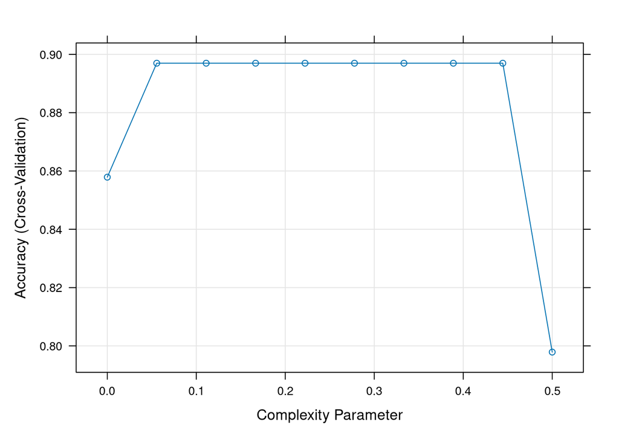

```r
plot(rpart.cv.10)
```

También, a través de la función `varImp()`, podemos obtener el información sobre la importancia de las variables para el proceso de clasificación, y junto con la función `plot()` verlo de forma gráfica.

```r
varImp(rpart.cv.10)
```

```
## rpart variable importance
##
##             Overall
## PROTIME      100.00
## ALBUMINA      72.82
## BILIRRUBINA   61.26
## ASCITIS       60.42
## VARICES       41.78
## MALAISE        0.00
## HISTIOLOGIA    0.00
## FOSFATOalc     0.00
## ARANIASvasc    0.00
## FATIGA         0.00
## BAZOpalpa      0.00
## EDAD           0.00
## HIGgrande      0.00
## SEXO           0.00
```

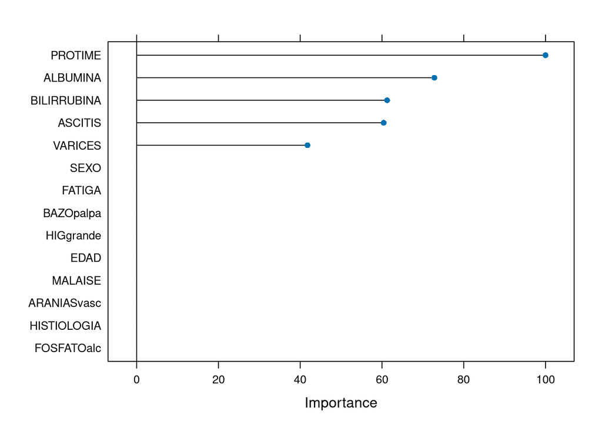

```r
plot(varImp(rpart.cv.10))
```

El objeto `rpart.cv.10` también incluye el clasificador más óptimo encontrado, almacenado en el campo `finalModel`. En este caso podemos visualizarlo a través de la librearía `partykit`. También se puede visualizar a través de la librería `rpart.plot`.

```r
library(partykit)
```

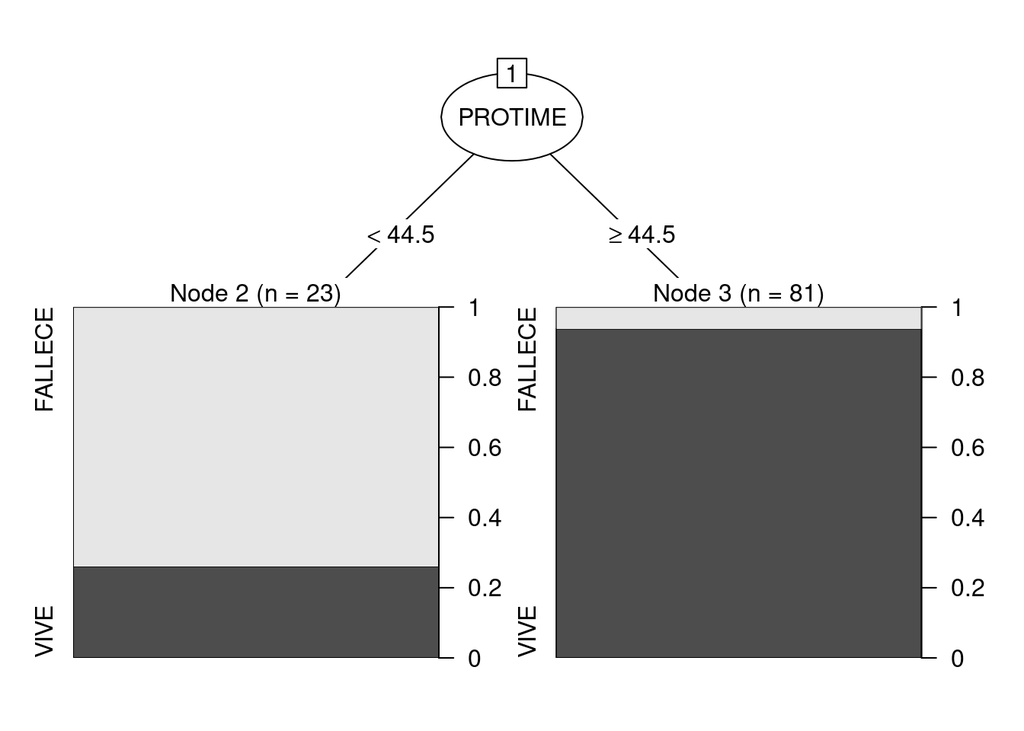

```r
plot(as.party(rpart.cv.10$finalModel))
```

**Ejercicio 5:**

Utiliza el conjunto de entrenamiento para generar los siguientes clasificadores: `C5.0`, `svmLinear`, `knn` y `lda`.

1. Los nombres de cada uno de los modelos deben ser `C50Fit`, `svmFit`, `knnFit` y `ldaFit` respectivamente.
2. Crea una tabla en que contenga los resultados de la precisión y el índice Kappa para cada uno de los modelos. Las filas llevarán el nombre de cada uno de los modelos y las columnas el nombre del índice correspondiente.

## 5.1 Preprocesamiento a través de la función `train()`

También es posible definir, a través de la función `train()`, el tipo de preprocesamiento que queremos aplicar a los datos utilizando el parámetro `preProcess`. Por ejemplo, si queremos que las ajustar los valores de los atributos de nuestro conjunto de datos para que estén en el intervalo [0, 1], podemos llamar a la función `train()` de la siguiente forma.

```r
set.seed(123)
seeds <- vector(mode = "list", length = 11)
for(i in 1:10) seeds[[i]] <- sample.int(1000, 4)
seeds[[11]] <- sample.int(1000, 1)


fit.control.cv.10.C50 <- trainControl(method = "cv",number=10,
                                      seeds = seeds,
                                      returnResamp = "all",
                                      verboseIter=TRUE,
                                      allowParallel = TRUE)

set.seed(342)
C50.cv.10.range<- train(PRONOSTICO~.,data=hepatitisTrain.sel,
                method="C5.0",
                preProc= "range",
                trControl = fit.control.cv.10.C50)
C50.cv.10.range
```

```
## C5.0
##
## 104 samples
##  14 predictor
##   2 classes: 'FALLECE', 'VIVE'
##
## Pre-processing: re-scaling to [0, 1] (14)
## Resampling: Cross-Validated (10 fold)
## Summary of sample sizes: 94, 94, 93, 94, 94, 94, ...
## Resampling results across tuning parameters:
##
##   model  winnow  trials  Accuracy   Kappa
##   rules  FALSE    1      0.8469697  0.4745747
##   rules  FALSE   10      0.8843939  0.6466337
##   rules  FALSE   20      0.8851515  0.6431062
##   rules   TRUE    1      0.8269697  0.4505984
##   rules   TRUE   10      0.8369697  0.4939596
##   rules   TRUE   20      0.8369697  0.4939596
##   tree   FALSE    1      0.8569697  0.4937135
##   tree   FALSE   10      0.8760606  0.6271893
##   tree   FALSE   20      0.8851515  0.6651203
##   tree    TRUE    1      0.8269697  0.4505984
##   tree    TRUE   10      0.8369697  0.4939596
##   tree    TRUE   20      0.8369697  0.4939596
##
## Accuracy was used to select the optimal model using the largest value.
## The final values used for the model were trials = 20, model = rules and
##  winnow = FALSE.
```

En el caso de que queramos realizar un análisis de componentes principales o independientes, habría que indicar el número de componentes a utilizar por medio de los correspondientes parámetros. El preprocesamiento de datos a través de la función `train()` permite que el clasificador creado tenga en cuenta la transformación realizada a la hora de realizar predicciones con conjunto de datos nuevos, es decir, será el propio clasificador quien aplique las transformaciones necesarias liberando a usuario de dicha tarea.

**Ejercicio 6:**

1. Vuelve a generar un clasificador C50 pero aplicando un centrado y un escalado (`center` y `scale`). Repite la operación aplicando un cambio de rango (`range`) ¿Encuentras diferencias? ¿Qué opción da mejor resultado?
2. Vuelve a generar una máquina de soporte de vectores con kernel lineal escalando y centrando los datos ¿Encuentras diferencias respecto a la calculada en el ejercicio anterior? ¿A qué crees que es debido?

## 5.2 Ajuste de hiperparámetros

En el caso de que tengamos información adicional sobre cuáles serían los posibles valores de los hiperparámetros que permitirían obtener el modelo óptimo, podemos definir dichos valores a través de la función `expand.grid()`.

Antes de definir el *grid* para la búsqueda de los hiperparámertos debemos saber cuáles son. Para ello, la función `modelLookup()`. Por ejemplo, para ver los parámetros que requiere red neuronal, basta con ejecutar:

```r
modelLookup("nnet")
```

```
##   model parameter         label forReg forClass probModel
## 1  nnet      size #Hidden Units   TRUE     TRUE      TRUE
## 2  nnet     decay  Weight Decay   TRUE     TRUE      TRUE
```

Con esta información ya podemos definir el *grid.* Por ejemplo, si queremos construir una red neuronal y sólo queremos probar configuraciones con 5, 10, 15 o 20 neuronas en la capa intermedia, con las siguientes tasas de aprendizaje: 0.5,0.1 y 0.001, sólo tendríamos que definir un nuevo *grid* búsqueda:

```r
nnetGrid <- expand.grid(size=c(5,10,15,20),
                        decay=c(0.5,0.1,0.001))

set.seed(123)
seeds <- vector(mode = "list", length = 11)
for(i in 1:10) seeds[[i]] <- sample.int(1000, 12)
seeds[[11]] <- sample.int(1000, 1)


fit.control.cv.10.nnet <- trainControl(method = "cv",number = 10,
                                       seeds = seeds,
                                       returnResamp = "all",
                                       verboseIter = FALSE,
                                       allowParallel = TRUE)
set.seed(342)
nnet.cv.10 <- train(PRONOSTICO~.,data=hepatitisTrain.sel,
                    method="nnet",
                    tuneGrid=nnetGrid,
                    trControl=fit.control.cv.10.nnet)
nnet.cv.10
```

```
## Neural Network
##
## 104 samples
##  14 predictor
##   2 classes: 'FALLECE', 'VIVE'
##
## No pre-processing
## Resampling: Cross-Validated (10 fold)
## Summary of sample sizes: 94, 94, 93, 94, 94, 94, ...
## Resampling results across tuning parameters:
##
##   size  decay  Accuracy   Kappa
##    5    0.001  0.8362121  0.4261899
##    5    0.100  0.8553030  0.5577502
##    5    0.500  0.8662121  0.5537439
##   10    0.001  0.8553030  0.5774180
##   10    0.100  0.8662121  0.5849243
##   10    0.500  0.8653030  0.5652351
##   15    0.001  0.8371212  0.4277328
##   15    0.100  0.8553030  0.5510009
##   15    0.500  0.8553030  0.5267736
##   20    0.001  0.8953030  0.6999425
##   20    0.100  0.8853030  0.6687840
##   20    0.500  0.8643939  0.5576845
##
## Accuracy was used to select the optimal model using the largest value.
## The final values used for the model were size = 20 and decay = 0.001.
```

La otra forma de realizar el ajuste de parámetros es utilizar en al función `train()` el parámetro `tuneLength` indicándole el número de valores que debe seleccionar para cada hiperparámetro. Esta opción se puede combinar con el parámetro `search` de la función `trtainControl()`. Con `search="grid"` se utiliza el método por defecto para la definición del *grid* de búsqueda de hiperparámetros. Con la opción `search="random"` se utiliza cierta información que se puede obtener de los modelos para optimizar la selección de valores sobre los que realizar la búsqueda.

**Ejercicio 7:**

1. Utiliza el código anterior y extiende el parámetro `size` para que busque la mejor red neuronales variando el numero de neuronas de la capa intermedia entre 10 y 20 neuronas.
2. Repite el proceso anterior pero realizando un centrado y escalado de los datos.
3. Elimina el *grid* definido, e introduce el parámetro `tuneLength=10` ¿Sobre qué valores realiza la búsqueda?
4. Entrena una máquina de soporte de vectores lineal haciendo que la función `train()` varíe el parámetro `C` entre los siguientes valores: 0.25, 0.5, 1, 2, 4, 8, 16, 32 y 64 ¿Con qué valor se obtiene el mejor resultado?.

## 5.3 Predicción

Para predecir las clases a los que pertenecen un conjunto de objetos nuevos tenemos que utilizar la función `predict()`. Por ejemplo, para para predecir las clases para el conjunto de prueba `hepatitisTest.sel`, utilizando el árbol anteriormente construido, bastaría con hacer:

```r
hepatitis.predict <- predict(rpart.cv.10,newdata = hepatitisTest.sel)
hepatitis.predict
```

```
##  [1] VIVE    FALLECE VIVE    VIVE    VIVE    VIVE    VIVE    VIVE    VIVE
## [10] VIVE    VIVE    FALLECE VIVE    VIVE    VIVE    VIVE    VIVE    VIVE
## [19] VIVE    VIVE    VIVE    VIVE    VIVE    VIVE    FALLECE FALLECE VIVE
## [28] FALLECE VIVE    VIVE    VIVE    FALLECE FALLECE VIVE    FALLECE VIVE
## [37] FALLECE VIVE    VIVE    VIVE    VIVE    VIVE    VIVE    FALLECE VIVE
## [46] VIVE    VIVE    VIVE    FALLECE VIVE    FALLECE
## Levels: FALLECE VIVE
```

También podemos obtener predicciones simultáneas para varios modelos. A continuación se calculan las predicciones en el conjunto de test para la red neuronal y el árbol anteriormente generados:

```r
models <- list(C50=C50.cv.10.range,Rpart=rpart.cv.10,Nnet = nnet.cv.10)
hepatitis.predict2 <- predict(models,newdata = hepatitisTest.sel)
hepatitis.predict2
```

```
## $C50
##  [1] VIVE    FALLECE VIVE    VIVE    VIVE    VIVE    VIVE    VIVE    VIVE
## [10] VIVE    VIVE    VIVE    VIVE    VIVE    VIVE    VIVE    VIVE    VIVE
## [19] VIVE    VIVE    VIVE    VIVE    VIVE    VIVE    FALLECE FALLECE VIVE
## [28] FALLECE VIVE    VIVE    VIVE    FALLECE FALLECE VIVE    FALLECE VIVE
## [37] FALLECE VIVE    VIVE    VIVE    VIVE    VIVE    VIVE    FALLECE VIVE
## [46] VIVE    VIVE    FALLECE FALLECE VIVE    FALLECE
## Levels: FALLECE VIVE
##
## $Rpart
##  [1] VIVE    FALLECE VIVE    VIVE    VIVE    VIVE    VIVE    VIVE    VIVE
## [10] VIVE    VIVE    FALLECE VIVE    VIVE    VIVE    VIVE    VIVE    VIVE
## [19] VIVE    VIVE    VIVE    VIVE    VIVE    VIVE    FALLECE FALLECE VIVE
## [28] FALLECE VIVE    VIVE    VIVE    FALLECE FALLECE VIVE    FALLECE VIVE
## [37] FALLECE VIVE    VIVE    VIVE    VIVE    VIVE    VIVE    FALLECE VIVE
## [46] VIVE    VIVE    VIVE    FALLECE VIVE    FALLECE
## Levels: FALLECE VIVE
##
## $Nnet
##  [1] VIVE    VIVE    VIVE    VIVE    VIVE    VIVE    VIVE    VIVE    VIVE
## [10] VIVE    VIVE    VIVE    VIVE    VIVE    FALLECE VIVE    VIVE    VIVE
## [19] VIVE    VIVE    VIVE    VIVE    VIVE    VIVE    FALLECE VIVE    VIVE
## [28] FALLECE VIVE    VIVE    VIVE    FALLECE FALLECE VIVE    VIVE    VIVE
## [37] FALLECE VIVE    VIVE    VIVE    VIVE    VIVE    VIVE    FALLECE VIVE
## [46] VIVE    VIVE    FALLECE FALLECE VIVE    VIVE
## Levels: FALLECE VIVE
```

Si queremos observar al mismo tiempo la clase asignada al objeto y la clase predicha por el modelo, debemos utilizar la función `extractPrediction()`:

```r
hepatitis.predict3 <- extractPrediction(models,
                          testX = hepatitisTest.sel[,-ncol(hepatitisTest.sel)],
                          testY = hepatitisTest.sel[,ncol(hepatitisTest.sel)])
datatable(hepatitis.predict3)
```

|  | obs | pred | model | dataType | object |
| --- | --- | --- | --- | --- | --- |
| 1 | VIVE | VIVE | C5.0 | Training | C50 |
| 2 | VIVE | VIVE | C5.0 | Training | C50 |
| 3 | VIVE | VIVE | C5.0 | Training | C50 |
| 4 | VIVE | VIVE | C5.0 | Training | C50 |
| 5 | VIVE | VIVE | C5.0 | Training | C50 |
| 6 | VIVE | VIVE | C5.0 | Training | C50 |
| 7 | VIVE | VIVE | C5.0 | Training | C50 |
| 8 | VIVE | VIVE | C5.0 | Training | C50 |
| 9 | VIVE | VIVE | C5.0 | Training | C50 |
| 10 | VIVE | VIVE | C5.0 | Training | C50 |

[output cut: 455 more lines]

Los objetos devueltos por la función pueden visualizarse a través de la función `plotObsVsPred()`. En el caso de que la variable dependiente sea un factor devuelve la *accuracy* alcanzada por cada modelo. En el caso de un problema de regresión visualiza para el valor real frente a la predicción.

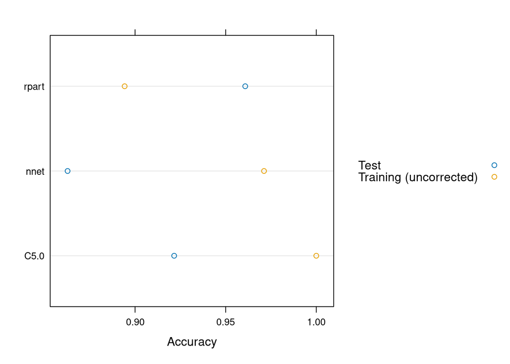

```r
plotObsVsPred(hepatitis.predict3, auto.key = TRUE)
```

Hay que tener cuidad con la gráfica anterior ya que muestra, como *accuracy* en training, el que mide en el resultado de la función `extractPrediction()` y no se corresponde con el valor de *accuarcy* obtenido al entrenar el modelo.

## 5.4 Área bajo la curva ROC

En el caso de problemas de clasificación en los que los objetos sólo pueden pertenecer a dos clases, se suele utilizar como medida de eficiencia del clasificador el **área bajo la curva ROC**. Si queremos que el modelo que construyamos utilice esta medida como medida de la eficacia del clasificador, deberemos indicar a través de las funciones `trainControl()` y `train()` que se va a utilizar dicha métrica.

En la función `trainControl()` le indicaremos que hay que calcular las probabilidades de pertenencia a las distintas clases mediante el parámetro `classProbs=TRUE` y que, además, que cómo métrica de eficiencia del clasificador se va a utilizar la definida para problemas con dos clases, que es el ROC, por medio del parámetro `summaryFunction = twoClassSummary`.

```r
set.seed(123)
seeds <- vector(mode = "list", length = 11)
for(i in 1:10) seeds[[i]] <- sample.int(1000, 10)
seeds[[11]] <- sample.int(1000, 1)



control.cv.10.ROC<- trainControl(method = "cv",number = 10,
                                 returnResamp = "final",
                                 seeds = seeds,
                                 summaryFunction = twoClassSummary,
                                 classProbs = TRUE,
                                 allowParallel = TRUE)
```

A la hora de invocar la función `train()` debemos advertirle de que se va a utilizar el ROC como métrica de la eficacia del clasificador mediante el parámetro `metric = "ROC"`.

```r
set.seed(342)
SVM.cv.10.ROC <- train(PRONOSTICO~.,data=hepatitisTrain.sel,
                       method="svmRadial",
                       tuneLength=10,
                       trControl = control.cv.10.ROC,
                       metric = "ROC")
SVM.cv.10.ROC
```

```
## Support Vector Machines with Radial Basis Function Kernel
##
## 104 samples
##  14 predictor
##   2 classes: 'FALLECE', 'VIVE'
##
## No pre-processing
## Resampling: Cross-Validated (10 fold)
## Summary of sample sizes: 94, 94, 93, 94, 94, 94, ...
## Resampling results across tuning parameters:
##
##   C       ROC        Sens       Spec
##     0.25  0.9018519  0.6500000  0.9152778
##     0.50  0.8956019  0.5500000  0.9277778
##     1.00  0.9030093  0.5833333  0.9375000
##     2.00  0.9004630  0.4500000  0.9500000
##     4.00  0.9064815  0.4833333  0.9500000
##     8.00  0.9027778  0.5166667  0.9625000
##    16.00  0.8881944  0.4666667  0.9625000
##    32.00  0.8819444  0.4666667  0.9500000
##    64.00  0.8819444  0.4166667  0.9625000
##   128.00  0.8819444  0.4166667  0.9500000
##
## Tuning parameter 'sigma' was held constant at a value of 0.05087504
## ROC was used to select the optimal model using the largest value.
## The final values used for the model were sigma = 0.05087504 and C = 4.
```

**Ejercicio 8:**

Cómo podéis ver, en el modelo generado se ha considerado la clase “VIVE” como clase negativa ¿Por qué? ¿Cómo se podría hacer para considerase “FALLECE” como clase positiva?

Como podemos ver, ahora la eficacia del modelo queda determinada por el índice ROC. Llegados a este punto también podemos calcular las probabilidades de la pertenencia a clases de cada ejemplo por medio de la función `predict()`:

```r
SVM.cv.10.ROC.prob <- predict(SVM.cv.10.ROC, newdata = hepatitisTest.sel,
                              type = "prob")
datatable(SVM.cv.10.ROC.prob)
```

|  | FALLECE | VIVE |
| --- | --- | --- |
| 1 | 0.07119445296918603 | 0.928805547030814 |
| 2 | 0.4907642552718383 | 0.5092357447281617 |
| 3 | 0.07664120405666908 | 0.9233587959433309 |
| 4 | 0.03803222993381972 | 0.9619677700661803 |
| 5 | 0.07990310490664865 | 0.9200968950933514 |
| 6 | 0.08113315366052831 | 0.9188668463394717 |
| 7 | 0.1312735995013051 | 0.8687264004986949 |
| 8 | 0.07735744763392782 | 0.9226425523660722 |
| 9 | 0.0806217997524441 | 0.9193782002475559 |
| 10 | 0.0648607624079981 | 0.9351392375920019 |

[output cut: 41 more lines]

El cálculo de la curva ROC lo podemos hacer utilizando el paquete `pROC`:

```r
library(pROC)
svmROC <- roc(hepatitisTest.sel$PRONOSTICO, SVM.cv.10.ROC.prob$VIVE)
svmROC
```

```
##
## Call:
## roc.default(response = hepatitisTest.sel$PRONOSTICO, predictor = SVM.cv.10.ROC.prob$VIVE)
##
## Data: SVM.cv.10.ROC.prob$VIVE in 10 controls (hepatitisTest.sel$PRONOSTICO FALLECE) < 41 cases (hepatitisTest.sel$PRONOSTICO VIVE).
## Area under the curve: 0.9512
```

Para visualizar la curva sólo tenemos que utilizar la función `plot()` con el objete `svmROC`.

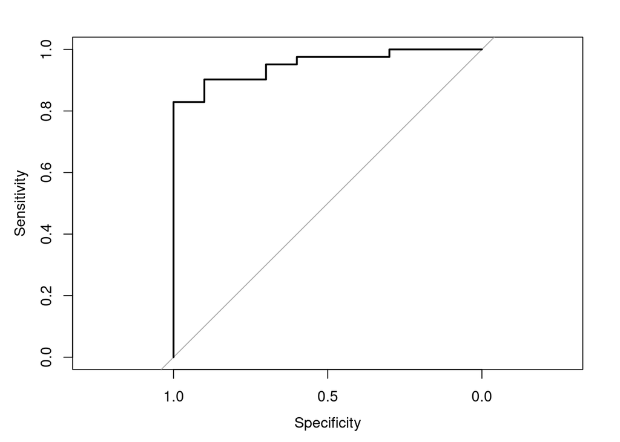

```r
plot(svmROC)
```

**Ejercicio 9:**

Calcula las probabilidades de clase y la curva ROC para 2 de los tres modelos de clasificación generados en los ejercicios anteriores.

## 5.5 Evaluación de los conjuntos de prueba

Con la función `confusionMatrix()` podemos crear un objeto que contiene todas las medidas incluidas en una matriz de confusión. Podemos utilizar esta función de dos formas. En primer lugar podemos calcular la matriz de confusión a partir del objeto devuelto por la función `train()` (siempre que no se utilice para el remuestreo los métodos `boot` o `LOOCV`). En este caso se utiliza la información procedente del proceso de remuestreo y sobre el conjunto de entrenamiento:

```r
hepatitis.conf <- confusionMatrix(C50.cv.10.range, positive = "VIVE")
hepatitis.conf
```

```
## Cross-Validated (10 fold) Confusion Matrix
##
## (entries are percentual average cell counts across resamples)
##
##           Reference
## Prediction FALLECE VIVE
##    FALLECE    14.4  4.8
##    VIVE        6.7 74.0
##
##  Accuracy (average) : 0.8846
```

La otra forma de calcular una matriz de confusión es la de utilizar directamente las clases predichas para el conjunto de prueba:

```r
hepatitis.pred <- predict(C50.cv.10.range,hepatitisTest.sel)
hepatitis.conf1 <- confusionMatrix(hepatitis.pred,
                                   hepatitisTest.sel[,ncol(hepatitisTest.sel)],
                                   positive = "VIVE")
hepatitis.conf1
```

```
## Confusion Matrix and Statistics
##
##           Reference
## Prediction FALLECE VIVE
##    FALLECE       9    3
##    VIVE          1   38
##
##                Accuracy : 0.9216
##                  95% CI : (0.8112, 0.9782)
##     No Information Rate : 0.8039
##     P-Value [Acc > NIR] : 0.01869
##
##                   Kappa : 0.7687
##
##  Mcnemar's Test P-Value : 0.61708
##
##             Sensitivity : 0.9268
##             Specificity : 0.9000
##          Pos Pred Value : 0.9744
##          Neg Pred Value : 0.7500
##              Prevalence : 0.8039
##          Detection Rate : 0.7451
##    Detection Prevalence : 0.7647
##       Balanced Accuracy : 0.9134
##
##        'Positive' Class : VIVE
##
```

**Ejercicio 10:**

Elige dos modelos de los anteriormente generados (ambos tienen que haber sido evaluados con la misma técnica).

1. Calcula la matriz de confusión y los principales índices de eficiencia de ambos modelos.
2. ¿Cuáles son los atributos del objeto generado por la función `confusionMatrix()`?
3. ¿Cómo podríamos generar una tabla con los nombres de los modelos en las filas y el de los indicadores en las columnas?

# 6 Comparación de modelos

El paquete `caret` también incluye funciones que nos permiten determinar las diferencias que existen entre distintos modelos, generados con la función `train()`, a través de un remuestreo de las distribuciones y obtener información estadística sobre la diferencia de efectividad de cada uno de ellos. Para poder hacer esto, primero debemos agrupar todos los resultados de remuestreo utilizando la función `resamples()`:

```r
hepatitis.resample <- resamples(models)
summary(hepatitis.resample)
```

```
##
## Call:
## summary.resamples(object = hepatitis.resample)
##
## Models: C50, Rpart, Nnet
## Number of resamples: 10
##
## Accuracy
##            Min. 1st Qu.    Median      Mean   3rd Qu. Max. NA's
## C50   0.6000000   0.850 0.9000000 0.8851515 0.9750000    1    0
## Rpart 0.7272727   0.850 0.9000000 0.8969697 0.9772727    1    0
## Nnet  0.7272727   0.825 0.9045455 0.8953030 0.9791667    1    0
##
## Kappa
##             Min.   1st Qu.    Median      Mean   3rd Qu. Max. NA's
## C50   -0.2500000 0.5705128 0.6761134 0.6431062 0.9342105    1    0
## Rpart  0.0000000 0.6008772 0.7368421 0.6742826 0.9360465    1    0
## Nnet   0.2325581 0.5629371 0.7405141 0.6999425 0.9375000    1    0
```

Existen diferentes funciones que nos permiten realizar gráficas para visualizar las distribuciones obtenidas a partir del remuestreo: `bwplots()`, para las gráficos de caja whisker, `densityplot()` para gráficos de densidad, `xyplot()` para gráficos de dispersión y `splom()` para gráficos de dispersión de resúmenes de estadísticos.

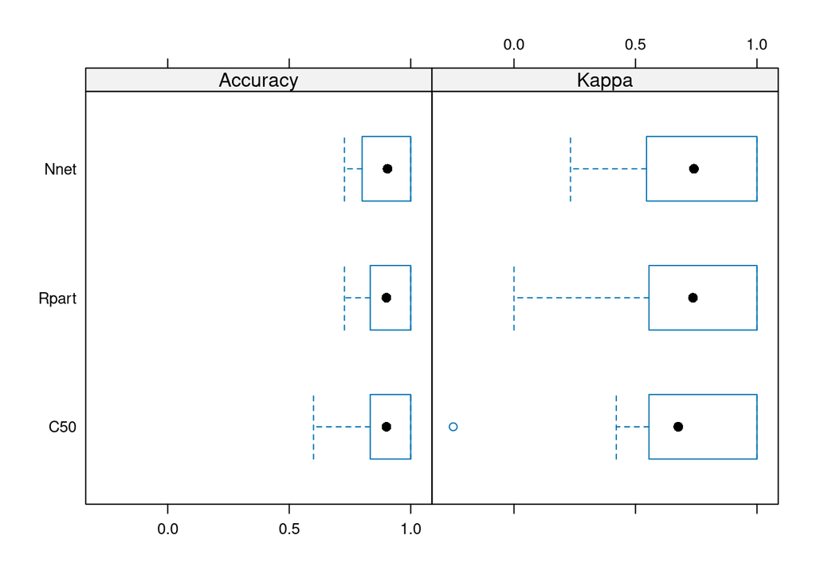

```r
bwplot(hepatitis.resample)
```

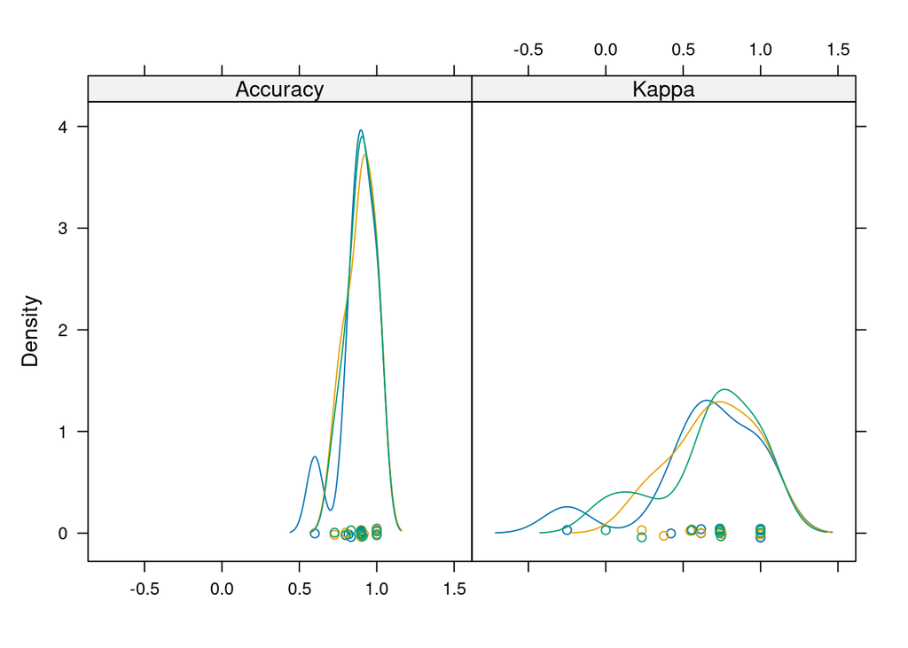

```r
densityplot(hepatitis.resample)
```

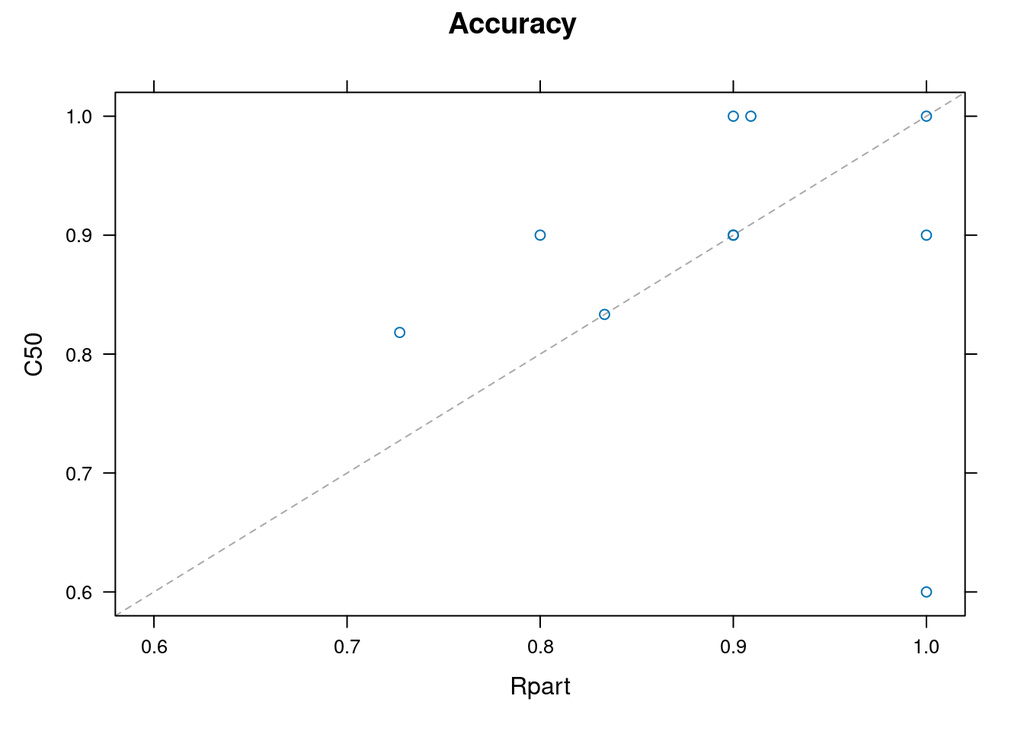

```r
xyplot(hepatitis.resample)
```

```r
difValues <- diff(hepatitis.resample)
summary(difValues)
```

```
##
## Call:
## summary.diff.resamples(object = difValues)
##
## p-value adjustment: bonferroni
## Upper diagonal: estimates of the difference
## Lower diagonal: p-value for H0: difference = 0
##
## Accuracy
##       C50 Rpart     Nnet
## C50       -0.011818 -0.010152
## Rpart 1              0.001667
## Nnet  1   1
##
## Kappa
##       C50 Rpart    Nnet
## C50       -0.03118 -0.05684
## Rpart 1            -0.02566
## Nnet  1   1
```

En la diagonal superior se pueden encontrar las estimaciones de las diferencias entre las medias de las medidas y en la diagonal inferior. En este caso, se puede observar que no podemos rechazar la hipótesis de que lo modelos presentan la misma eficacia (las medias son iguales $H_0:\mu_0=\mu_1$), al ser los p-values mayores que la significancia por defecto 0.05.

Los resultados sobre las diferencias entre métodos se pueden mostrar de forma gráfica a través de diferentes tipos de gráficas:

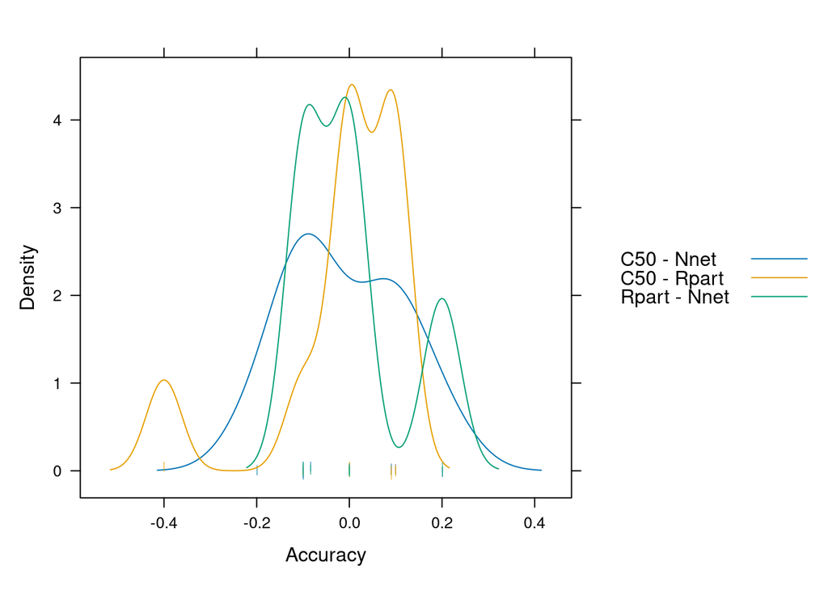

```r
densityplot(difValues, metric = "Accuracy",auto.key =TRUE, pch = "|")
```

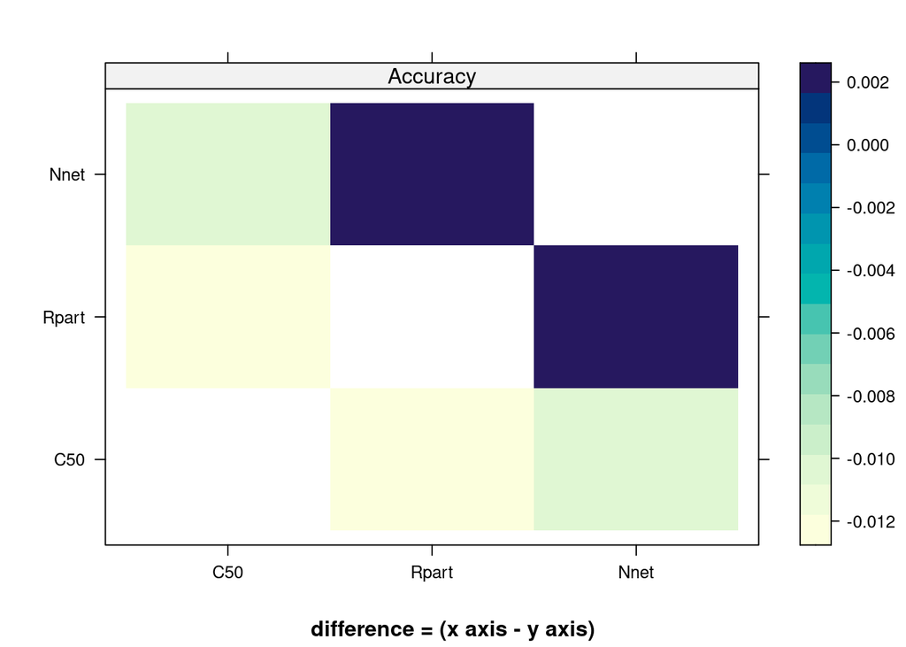

```r
levelplot(difValues, what="diferences")
```

**Ejercicio 11:**

Selecciona dos modelos de los anteriormente generados

1. Extrae la información sobre el muestreo de los dos modelos y muestra un resumen con las medidas utilizadas para su evaluación.
2. Genera algunas gráficas que muestren el resultado de la operación anterior.
3. Aplica el test T de Student e interpreta el resultado.
4. La función `compare_models()` también realiza el mismo test. Aplícala y analiza los resultados.
[^1]: Para una lista más completa de parámetros consultar la documentación del paquete `caret`.